# Сетевые технологии

Доклад на тему “Технология виртуальных частных сетей VPN”

Тойчубекова Асель Нурлановна

kulyabov-ds@rudn.ru

Российский университет дружбы народов

2025-11-21

# Информация

## Докладчик

- Тойчубекова Асель Нурлановна
- Студент 3 курса
- факультет физико-математических и естественных наук
- Российский университет дружбы народов им. П. Лумумбы
- 1032235033@rudn.ru

# Цель доклада

## Цель доклада

Цель доклада — рассмотреть технологию виртуальных частных сетей (VPN), раскрыть принципы её работы, основные типы VPN, используемые методы шифрования, аутентификации и туннелирования, а также показать современные тенденции развития VPN в условиях роста удалённой работы и облачных сервисов.

# Виртуальная частная сеть VPN

## Виртуальная частная сеть VPN

В современном мире интернет является основой для общения, работы и обмена данными. Однако публичные сети остаются уязвимыми: передаваемая информация может быть перехвачена или изменена.

VPN (Virtual Private Network) — это технология, позволяющая создать защищённый виртуальный канал поверх публичной сети.

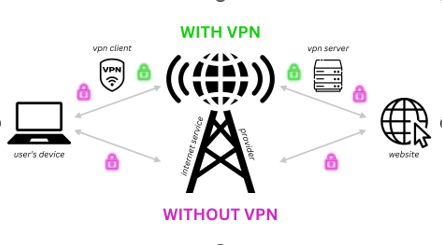

VPN (Virtual Private Network)

## Предназначение VPN

Сущность VPN можно рассматривать с разных точек зрения:

1. Криптографическая защита трафика — шифрование и контроль целостности данных.
2. Безопасный удалённый доступ — подключение к корпоративной сети из любой точки мира.
3. Экономичная альтернатива выделенным каналам — использование общедоступных сетей вместо дорогих линий связи.

## Предназначение VPN

4. Сокрытие сетевой топологии — маскировка внутренних IP-адресов и структуры сети.
5. Анонимность и приватность — скрытие личности и местоположения пользователя.
6. Обход ограничений и цензуры — доступ к заблокированным ресурсам и сервисам.
7. Сегментация и объединение сетей — создание единого защищённого пространства для распределённых сетей.

## Типы VPN

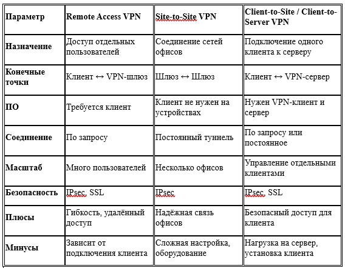

Типы VPN

# История развития VPN

## История развития VPN

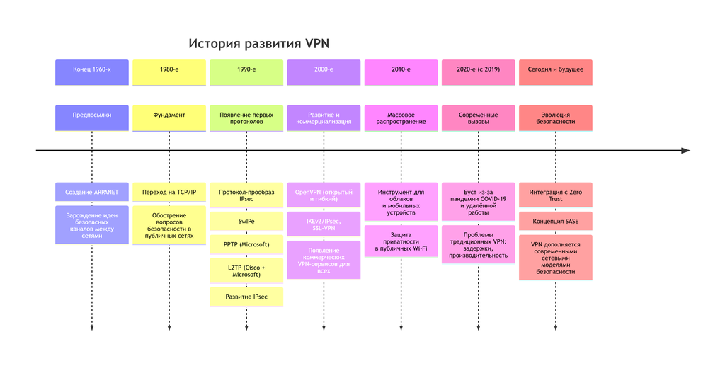

История развития VPN

# Основные концепции и принципы работы VPN

## Основные концепции и принципы работы VPN

Архитектура VPN включает три ключевых элемента: туннелирование, криптографию и аутентификацию. Основные компоненты работы VPN:

- VPN-клиент — инициирует подключение, выполняет аутентификацию и шифрование трафика на устройстве пользователя.
- VPN-сервер (шлюз) — принимает соединения, проверяет подлинность, расшифровывает данные и передаёт их во внутреннюю сеть.
- VPN-туннель — защищённый виртуальный канал в публичной сети.
- VPN-протоколы — определяют правила установления туннеля, шифрования и аутентификации.

## Туннелирование

Туннелирование — это механизм, при котором один сетевой пакет инкапсулируется в другой, чтобы безопасно пройти через публичную сеть.

Туннелирование включает:

- Протокол-пассажир — исходный пакет, который нужно доставить.
- Несущий протокол — транспортирует инкапсулированные данные через интернет.
- Протокол туннелирования — определяет правила упаковки и распаковки.

## Шифрование

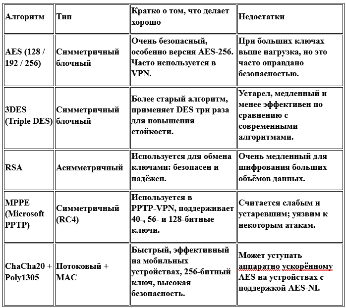

Алгоритмы шифрования

## Аутентификация

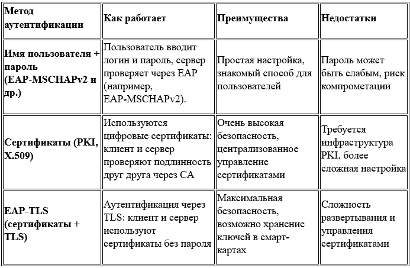

Методы аутентификации

# Протоколы VPN

## Протоколы VPN

VPN использует туннельные протоколы, которые инкапсулируют и шифруют данные, обеспечивая их безопасную передачу через интернет. Разные протоколы используют различные методы шифрования, аутентификации и установки соединения, обеспечивая нужный уровень защиты.

Туннельные протоколы VPN работают на разных уровнях модели OSI:

- Канальный уровень
- Сетевой уровень
- Транспортный уровень

## Канальный уровень

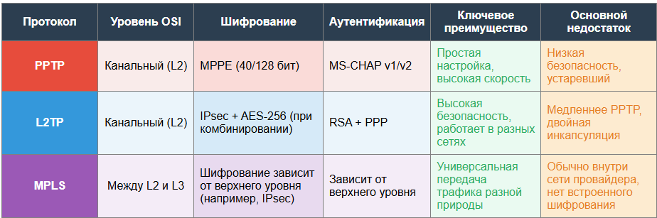

Протоколы канального уровня

## Сетевой уровень

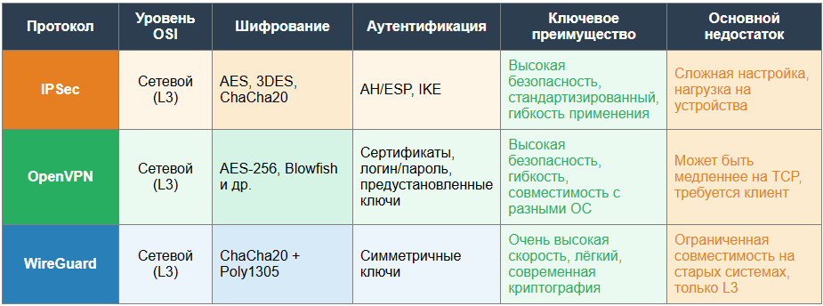

Протоколы сетевого уровня

## Транспортный уровень

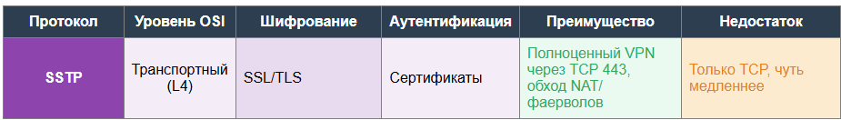

Протокол транспортного уровня

## Современные Тенденции

Проблема традиционного VPN: один общий туннель даёт доступ ко всей сети и заставляет весь трафик идти через дата-центр → задержки и перегрузка.

Современные подходы:

- Split Tunneling — корпоративный трафик через VPN, остальной — напрямую.
- Zero Trust — доступ только к нужным приложениям, а не ко всей сети.
- SASE — облачная безопасная точка доступа, направляющая трафик напрямую к корпоративным и облачным сервисам.

# Заключение

## Заключение

VPN — ключевая технология информационной безопасности, позволяющая создавать защищённые каналы поверх публичных сетей. Она обеспечивает конфиденциальность, защиту данных и безопасное объединение распределённых ресурсов.

В условиях роста удалённой работы и использования облаков VPN остаётся критически важным инструментом: шифрование, аутентификация и туннелирование надёжно защищают трафик от перехвата.

Типы VPN (Remote Access, Site-to-Site, Client-to-Site) обеспечивают гибкость и подходят как частным пользователям, так и крупным организациям.

# Список литературы

## Список литературы

1. Запечников С.В., Милославская Н.Г., Толстой А.И. Основы построения виртуальных частных сетей. Учебное пособие.
2. Selectel. VPN-туннели: что это и как работают. URL: https://selectel.ru/blog/vpn-tunnel/
3. LANmarket. Что такое VPN и как он работает. URL: https://lanmarket.ua/entsiklopediya/telekommunikatsionnye-tekhnologii/vpn.html
4. BStudy.net. Основные виды технической реализации VPN. URL: https://bstudy.net/866017/tehnika/osnovnye_vidy_tehnicheskoy_realizatsii#790473
5. Seti.ucoz.ru. Лекция 4: Программное обеспечение VPN, структура и классификация. URL: https://seti.ucoz.ru/index/lekcija_4_programmnoe_obespechenie_virtualnykh_chastnykh_setej_vpn_struktura_vpn_klassifikacija_vpn/0-22